# Revenue Analysis : The Movie Database

- Introduction
- Data Wrangling
- Exploratory Data Analysis
- Conclusions

## Introduction

This data set contains information about 10,000 movies collected from The Movie Database (TMDb), including user ratings and revenue. It has 10,866 rows and 21 columns. The source of this data set is Kaggle.

**Explanation of the columns:**

id: unique id for each movie  
imdb_id: unique id given by imdb for each movie  
popularity: Popularity of the movie  
budget: Movie budget in dollars  
revenue: Movie revenue in dollars  
original_title: Movie title  
cast: Movie cast  
homepage: website of the movie  
director: Director/s of the movie  
tagline: Tagline  
keywords: Keyowords of the movie  
overview: Movie overview  
runtime: Runtime of the movie  
genres: Movie genre  
production_companies: Production company  
release_date: Release_date of the movie  
vote_count: Vote counts  
vote_average: Average vote counts  
release_year: Release year of the movie  
budget_adj: Inflation adjusted budget of the movie  
revenue_adj: Inflation adjusted revenue of the movie  
budget_adj_mil: Inflation adjusted budget of the movie (in millions) (added later for analysis)  
rev_adj_mil: Inflation adjusted revenue of the movie (in millions) (added later for analysis)

**Research questions:**

1. What features are associated with higher revenue?
2. How does the revenue trend look like over years?
3. How are inflation adjusted budget and revenue are related? Does higher budget mean higher revenue?
4. Does higher vote lead to higher revenue?
5. How does runtime affect the revenue?

```python
# Import packages
import pandas as pd
import numpy as np
import seaborn as sns
import matplotlib.pyplot as plt
%matplotlib inline
from datetime import datetime
```

## Data Wrangling

### General Properties

```python
# Loading the data and checking first few lines
df = pd.read_csv("tmdb-movies.csv")
df.head(3)
```

|  | id | imdb_id | popularity | budget | revenue | original_title | cast | homepage | director | tagline | ... | overview | runtime | genres | production_companies | release_date | vote_count | vote_average | release_year | budget_adj | revenue_adj |
| --- | --- | --- | --- | --- | --- | --- | --- | --- | --- | --- | --- | --- | --- | --- | --- | --- | --- | --- | --- | --- | --- |
| 0 | 135397 | tt0369610 | 32.985763 | 150000000 | 1513528810 | Jurassic World | Chris Pratt\|Bryce Dallas Howard\|Irrfan Khan\|Vi... | http://www.jurassicworld.com/ | Colin Trevorrow | The park is open. | ... | Twenty-two years after the events of Jurassic ... | 124 | Action\|Adventure\|Science Fiction\|Thriller | Universal Studios\|Amblin Entertainment\|Legenda... | 6/9/15 | 5562 | 6.5 | 2015 | 1.379999e+08 | 1.392446e+09 |
| 1 | 76341 | tt1392190 | 28.419936 | 150000000 | 378436354 | Mad Max: Fury Road | Tom Hardy\|Charlize Theron\|Hugh Keays-Byrne\|Nic... | http://www.madmaxmovie.com/ | George Miller | What a Lovely Day. | ... | An apocalyptic story set in the furthest reach... | 120 | Action\|Adventure\|Science Fiction\|Thriller | Village Roadshow Pictures\|Kennedy Miller Produ... | 5/13/15 | 6185 | 7.1 | 2015 | 1.379999e+08 | 3.481613e+08 |
| 2 | 262500 | tt2908446 | 13.112507 | 110000000 | 295238201 | Insurgent | Shailene Woodley\|Theo James\|Kate Winslet\|Ansel... | http://www.thedivergentseries.movie/#insurgent | Robert Schwentke | One Choice Can Destroy You | ... | Beatrice Prior must confront her inner demons ... | 119 | Adventure\|Science Fiction\|Thriller | Summit Entertainment\|Mandeville Films\|Red Wago... | 3/18/15 | 2480 | 6.3 | 2015 | 1.012000e+08 | 2.716190e+08 |

3 rows × 21 columns

```python
# finding out general properties of the data like data type, nulls
df.info()
```

```
<class 'pandas.core.frame.DataFrame'>
RangeIndex: 10866 entries, 0 to 10865
Data columns (total 21 columns):
id                      10866 non-null int64
imdb_id                 10856 non-null object
popularity              10866 non-null float64
budget                  10866 non-null int64
revenue                 10866 non-null int64
original_title          10866 non-null object
cast                    10790 non-null object
homepage                2936 non-null object
director                10822 non-null object
tagline                 8042 non-null object
keywords                9373 non-null object
overview                10862 non-null object
runtime                 10866 non-null int64
genres                  10843 non-null object
production_companies    9836 non-null object
release_date            10866 non-null object
vote_count              10866 non-null int64
vote_average            10866 non-null float64
release_year            10866 non-null int64
budget_adj              10866 non-null float64
revenue_adj             10866 non-null float64
dtypes: float64(4), int64(6), object(11)
memory usage: 1.7+ MB
```

```python
# Learning about the distribution of the data
df.describe()
```

|  | id | popularity | budget | revenue | runtime | vote_count | vote_average | release_year | budget_adj | revenue_adj |
| --- | --- | --- | --- | --- | --- | --- | --- | --- | --- | --- |
| count | 10866.000000 | 10866.000000 | 1.086600e+04 | 1.086600e+04 | 10866.000000 | 10866.000000 | 10866.000000 | 10866.000000 | 1.086600e+04 | 1.086600e+04 |
| mean | 66064.177434 | 0.646441 | 1.462570e+07 | 3.982332e+07 | 102.070863 | 217.389748 | 5.974922 | 2001.322658 | 1.755104e+07 | 5.136436e+07 |
| std | 92130.136561 | 1.000185 | 3.091321e+07 | 1.170035e+08 | 31.381405 | 575.619058 | 0.935142 | 12.812941 | 3.430616e+07 | 1.446325e+08 |
| min | 5.000000 | 0.000065 | 0.000000e+00 | 0.000000e+00 | 0.000000 | 10.000000 | 1.500000 | 1960.000000 | 0.000000e+00 | 0.000000e+00 |
| 25% | 10596.250000 | 0.207583 | 0.000000e+00 | 0.000000e+00 | 90.000000 | 17.000000 | 5.400000 | 1995.000000 | 0.000000e+00 | 0.000000e+00 |
| 50% | 20669.000000 | 0.383856 | 0.000000e+00 | 0.000000e+00 | 99.000000 | 38.000000 | 6.000000 | 2006.000000 | 0.000000e+00 | 0.000000e+00 |
| 75% | 75610.000000 | 0.713817 | 1.500000e+07 | 2.400000e+07 | 111.000000 | 145.750000 | 6.600000 | 2011.000000 | 2.085325e+07 | 3.369710e+07 |
| max | 417859.000000 | 32.985763 | 4.250000e+08 | 2.781506e+09 | 900.000000 | 9767.000000 | 9.200000 | 2015.000000 | 4.250000e+08 | 2.827124e+09 |

### Data Cleaning

1. Change the data type of the following:  
   release_date to date  
   release_year to categorical value
2. Check the data for duplicates and remove them, if any

Columns to be used for research questions, do not have any nulls. Hence, they are not required to be cleaned.

```python
# Step 1.code: changing data type of release_date and year
df.release_date = pd.to_datetime(df.release_date)
df.release_year = df.release_year.astype("category")
```

```python
# Step 1.test: testing the above code
df.info()
df.head(3)
```

```
<class 'pandas.core.frame.DataFrame'>
RangeIndex: 10866 entries, 0 to 10865
Data columns (total 21 columns):
id                      10866 non-null int64
imdb_id                 10856 non-null object
popularity              10866 non-null float64
budget                  10866 non-null int64
revenue                 10866 non-null int64
original_title          10866 non-null object
cast                    10790 non-null object
homepage                2936 non-null object
director                10822 non-null object
tagline                 8042 non-null object
keywords                9373 non-null object
overview                10862 non-null object
runtime                 10866 non-null int64
genres                  10843 non-null object
production_companies    9836 non-null object
release_date            10866 non-null datetime64[ns]
vote_count              10866 non-null int64
vote_average            10866 non-null float64
release_year            10866 non-null category
budget_adj              10866 non-null float64
revenue_adj             10866 non-null float64
dtypes: category(1), datetime64[ns](1), float64(4), int64(5), object(10)
memory usage: 1.7+ MB
```

|  | id | imdb_id | popularity | budget | revenue | original_title | cast | homepage | director | tagline | ... | overview | runtime | genres | production_companies | release_date | vote_count | vote_average | release_year | budget_adj | revenue_adj |
| --- | --- | --- | --- | --- | --- | --- | --- | --- | --- | --- | --- | --- | --- | --- | --- | --- | --- | --- | --- | --- | --- |
| 0 | 135397 | tt0369610 | 32.985763 | 150000000 | 1513528810 | Jurassic World | Chris Pratt\|Bryce Dallas Howard\|Irrfan Khan\|Vi... | http://www.jurassicworld.com/ | Colin Trevorrow | The park is open. | ... | Twenty-two years after the events of Jurassic ... | 124 | Action\|Adventure\|Science Fiction\|Thriller | Universal Studios\|Amblin Entertainment\|Legenda... | 2015-06-09 | 5562 | 6.5 | 2015 | 1.379999e+08 | 1.392446e+09 |
| 1 | 76341 | tt1392190 | 28.419936 | 150000000 | 378436354 | Mad Max: Fury Road | Tom Hardy\|Charlize Theron\|Hugh Keays-Byrne\|Nic... | http://www.madmaxmovie.com/ | George Miller | What a Lovely Day. | ... | An apocalyptic story set in the furthest reach... | 120 | Action\|Adventure\|Science Fiction\|Thriller | Village Roadshow Pictures\|Kennedy Miller Produ... | 2015-05-13 | 6185 | 7.1 | 2015 | 1.379999e+08 | 3.481613e+08 |
| 2 | 262500 | tt2908446 | 13.112507 | 110000000 | 295238201 | Insurgent | Shailene Woodley\|Theo James\|Kate Winslet\|Ansel... | http://www.thedivergentseries.movie/#insurgent | Robert Schwentke | One Choice Can Destroy You | ... | Beatrice Prior must confront her inner demons ... | 119 | Adventure\|Science Fiction\|Thriller | Summit Entertainment\|Mandeville Films\|Red Wago... | 2015-03-18 | 2480 | 6.3 | 2015 | 1.012000e+08 | 2.716190e+08 |

3 rows × 21 columns

```python
# Step 2.a (code): Checking for duplicates
df[df.duplicated()]
```

|  | id | imdb_id | popularity | budget | revenue | original_title | cast | homepage | director | tagline | ... | overview | runtime | genres | production_companies | release_date | vote_count | vote_average | release_year | budget_adj | revenue_adj |
| --- | --- | --- | --- | --- | --- | --- | --- | --- | --- | --- | --- | --- | --- | --- | --- | --- | --- | --- | --- | --- | --- |
| 2090 | 42194 | tt0411951 | 0.59643 | 30000000 | 967000 | TEKKEN | Jon Foo\|Kelly Overton\|Cary-Hiroyuki Tagawa\|Ian... | NaN | Dwight H. Little | Survival is no game | ... | In the year of 2039, after World Wars destroy ... | 92 | Crime\|Drama\|Action\|Thriller\|Science Fiction | Namco\|Light Song Films | 2010-03-20 | 110 | 5.0 | 2010 | 30000000.0 | 967000.0 |

1 rows × 21 columns

```python
# Step 2.b (test): Dropping duplicates
df.drop_duplicates(inplace = True)
```

```python
# Step 3.a: Checking for adjusted budget column where the values are 0
df[df.budget_adj == 0]
```

[output not shown]

5696 rows × 21 columns

```python
# Checking for adjusted budget column where the values are 0
df[df.revenue_adj == 0]
```

[output not shown]

6016 rows × 21 columns

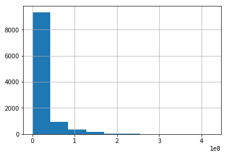

```python
df.budget_adj.hist()
```

```python
[df.budget_adj.mean(),df.budget_adj.median()]
```

```
[17549894.037320547, 0.0]
```

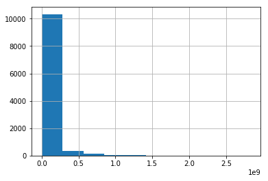

```python
df.revenue_adj.hist()
```

```python
[df.revenue.mean(),df.revenue_adj.median()]
```

```
[39826896.076852277, 0.0]
```

```python
# Step 3.b (code) : Replacing the 0 values of adjusted budget and revenue column with mean/avg as median is 0
df.budget_adj.replace(0, df.budget_adj.mean(), inplace= True)
df.revenue_adj.replace(0, df.revenue_adj.mean(), inplace= True)
```

```python
# Step 3.c (Test): Testing whether the values have been successfully replaced
len(df[df.budget_adj == 0])
```

```
0
```

```python
# Testing whether the values have been successfully replaced
len(df[df.revenue_adj == 0])
```

```
0
```

### Exploratory Data Analysis

### Research Question 1: What features are associated with higher revenue?

```python
# Step 4.a (Code): For the purpose of analysis, convert budget_adj and rev_adj to millions

df['budget_adj_mil'] = round(df.budget_adj/1000000,2)
df['rev_adj_mil'] = round(df.revenue_adj/1000000,2)
```

```python
# Step 4.b (Test):Testing the above converted columns
df.info()
df.head(3)
```

```
<class 'pandas.core.frame.DataFrame'>
Int64Index: 10865 entries, 0 to 10865
Data columns (total 23 columns):
id                      10865 non-null int64
imdb_id                 10855 non-null object
popularity              10865 non-null float64
budget                  10865 non-null int64
revenue                 10865 non-null int64
original_title          10865 non-null object
cast                    10789 non-null object
homepage                2936 non-null object
director                10821 non-null object
tagline                 8041 non-null object
keywords                9372 non-null object
overview                10861 non-null object
runtime                 10865 non-null int64
genres                  10842 non-null object
production_companies    9835 non-null object
release_date            10865 non-null datetime64[ns]
vote_count              10865 non-null int64
vote_average            10865 non-null float64
release_year            10865 non-null category
budget_adj              10865 non-null float64
revenue_adj             10865 non-null float64
budget_adj_mil          10865 non-null float64
rev_adj_mil             10865 non-null float64
dtypes: category(1), datetime64[ns](1), float64(6), int64(5), object(10)
memory usage: 1.9+ MB
```

|  | id | imdb_id | popularity | budget | revenue | original_title | cast | homepage | director | tagline | ... | genres | production_companies | release_date | vote_count | vote_average | release_year | budget_adj | revenue_adj | budget_adj_mil | rev_adj_mil |
| --- | --- | --- | --- | --- | --- | --- | --- | --- | --- | --- | --- | --- | --- | --- | --- | --- | --- | --- | --- | --- | --- |
| 0 | 135397 | tt0369610 | 32.985763 | 150000000 | 1513528810 | Jurassic World | Chris Pratt\|Bryce Dallas Howard\|Irrfan Khan\|Vi... | http://www.jurassicworld.com/ | Colin Trevorrow | The park is open. | ... | Action\|Adventure\|Science Fiction\|Thriller | Universal Studios\|Amblin Entertainment\|Legenda... | 2015-06-09 | 5562 | 6.5 | 2015 | 1.379999e+08 | 1.392446e+09 | 138.0 | 1392.45 |
| 1 | 76341 | tt1392190 | 28.419936 | 150000000 | 378436354 | Mad Max: Fury Road | Tom Hardy\|Charlize Theron\|Hugh Keays-Byrne\|Nic... | http://www.madmaxmovie.com/ | George Miller | What a Lovely Day. | ... | Action\|Adventure\|Science Fiction\|Thriller | Village Roadshow Pictures\|Kennedy Miller Produ... | 2015-05-13 | 6185 | 7.1 | 2015 | 1.379999e+08 | 3.481613e+08 | 138.0 | 348.16 |
| 2 | 262500 | tt2908446 | 13.112507 | 110000000 | 295238201 | Insurgent | Shailene Woodley\|Theo James\|Kate Winslet\|Ansel... | http://www.thedivergentseries.movie/#insurgent | Robert Schwentke | One Choice Can Destroy You | ... | Adventure\|Science Fiction\|Thriller | Summit Entertainment\|Mandeville Films\|Red Wago... | 2015-03-18 | 2480 | 6.3 | 2015 | 1.012000e+08 | 2.716190e+08 | 101.2 | 271.62 |

3 rows × 23 columns

|  | runtime | vote_average | budget_adj_mil | rev_adj_mil |
| --- | --- | --- | --- | --- |
| runtime | 1.000000 | 0.156813 | 0.204833 | 0.154509 |
| vote_average | 0.156813 | 1.000000 | 0.087896 | 0.173239 |
| budget_adj_mil | 0.204833 | 0.087896 | 1.000000 | 0.602134 |
| rev_adj_mil | 0.154509 | 0.173239 | 0.602134 | 1.000000 |

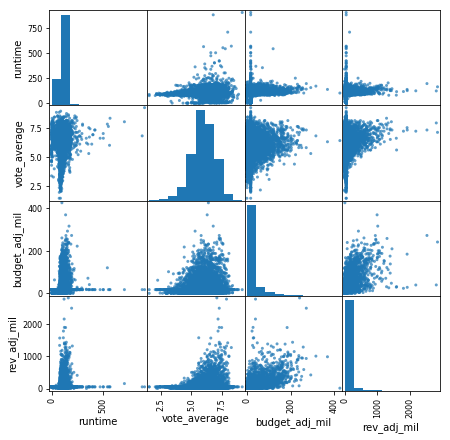

```python
#Step 5:applicable to research question 1
# Below block of code is used to find correlation between different quantitative variables and they are plotted on the
# scatter to view their relationship

pd.plotting.scatter_matrix(df[['runtime','vote_average','budget_adj_mil', 'rev_adj_mil']], figsize = (7,7), alpha=0.7);
df[['runtime','vote_average','budget_adj_mil', 'rev_adj_mil']].corr()
```

**1.a Conclusion:** From the above correlation matrix and the scatter plot, it can be observed that the correlation between inflation adjusted budget and revenue is stronger as compared to other variables

### Research Question 2: How does the revenue trend look like over years?

```
Text(0,0.5,'Inflation-adjusted revenue (in millions)')
```

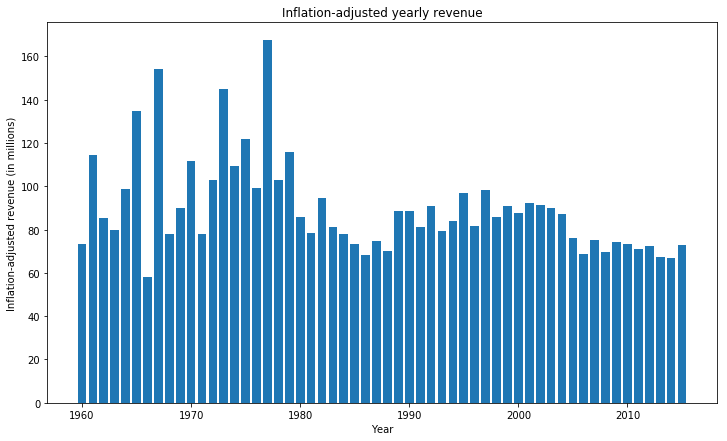

```python
# Step 6:applicable to research question 2
# Below block of code is used to find the average revenue by grouping on aggregating on release year using group by function
# Once obtained, values are plotted to find out the trend

rev_data_year = df.groupby(by= 'release_year').mean()["rev_adj_mil"]
plt.figure(figsize= (12,7))
plt.bar(x= rev_data_year.index, height = rev_data_year)
plt.title("Inflation-adjusted yearly revenue")
plt.xlabel('Year')
plt.ylabel("Inflation-adjusted revenue (in millions)")
```

**2.a Conclusion:** The average revenue trend over years is very erratic. Highest average revenue was observed in year 1977. Although it might be assumed that the trend would be upward based on the availability of different mediums to watch movies, the actual trend observed is very different than the general notion.

### Research Question 3: How are inflation adjusted budget and revenue are related? Does higher budget mean higher revenue?

|  | budget_adj_mil | rev_adj_mil |
| --- | --- | --- |
| budget_adj_mil | 1.000000 | 0.602134 |
| rev_adj_mil | 0.602134 | 1.000000 |

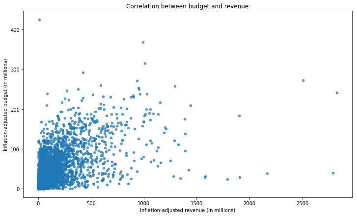

```python
# Step 7:applicable to research question 3
# Below block of code is used to plot inflation adjusted budget and revenue in form of a scatter plot to find out
# the relationship between two variables

df.plot(y= "budget_adj_mil", x = "rev_adj_mil", kind = "scatter", figsize= (12,7), alpha = 0.7)
plt.title("Correlation between budget and revenue")
plt.xlabel('Inflation-adjusted revenue (in millions)')
plt.ylabel("Inflation-adjusted budget (in millions)")

df[["budget_adj_mil","rev_adj_mil"]].corr()
```

### Research Question 4: Does higher vote lead to higher revenue?

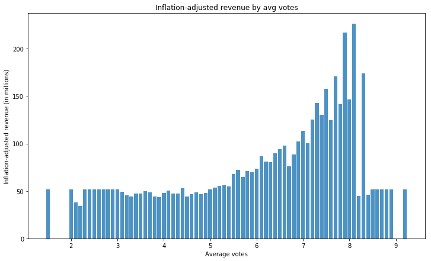

```python
# Step 8:applicable to research question 4
# Below block of code is used to find the average revenue by grouping on aggregating on average votes using groupby function
# Once obtained, these values are plotted to find out the trend

rev_data_votes = df.groupby(by= 'vote_average').mean()["rev_adj_mil"]
plt.figure(figsize=(12,7))
plt.bar(x= rev_data_votes.index, height= rev_data_votes, alpha = 0.8, width = 0.08)
plt.title("Inflation-adjusted revenue by avg votes")
plt.xlabel('Average votes')
plt.ylabel("Inflation-adjusted revenue (in millions)")
plt.show()
```

**4.a Conclusion:** From the above bar plot, it can be observed that the revenue increases with the increase in the average votes except when the votes crosses 8.1. This might be because there might not be sufficient samples pertaining to that average votes.

### Research Question 5: How does runtime affect the revenue?

```python
# Step 9: applicable to research question 5
# Below block of codes are for defining the function for converting the runtime into categorical variable for analysis
# Once the new variable is calculated, avg revenue is calculated by using group by on that variable
# After that an order is set for runtime categories
# Once these values are plotted the give an idea about avg revenue for each category

def hr_fun (x):
    if x < 60:
        return "Less than 1 hr"
    elif x < 120:
        return "Between 1 & 2 hrs"
    elif x <180:
        return "Between 2 & 3 hrs"
    else:
        return "Greater than 3 hrs"
```

```python
df["runtime_summary"] = df.runtime.apply(hr_fun)
```

```python
rev_data_runtime = df.groupby("runtime_summary").mean()["rev_adj_mil"]
```

```python
revdf = pd.DataFrame(rev_data_runtime)
revdf.reset_index(inplace = True)
```

```python
revdf.runtime_summary = revdf.runtime_summary.astype("category")
```

```python
revdf.runtime_summary
```

```
0     Between 1 & 2 hrs
1     Between 2 & 3 hrs
2    Greater than 3 hrs
3        Less than 1 hr
Name: runtime_summary, dtype: category
Categories (4, object): [Between 1 & 2 hrs, Between 2 & 3 hrs, Greater than 3 hrs, Less than 1 hr]
```

```python
#testing the categorical values
revdf.info()
revdf.runtime_summary
```

```
<class 'pandas.core.frame.DataFrame'>
RangeIndex: 4 entries, 0 to 3
Data columns (total 2 columns):
runtime_summary    4 non-null category
rev_adj_mil        4 non-null float64
dtypes: category(1), float64(1)
memory usage: 308.0 bytes
```

```
0     Between 1 & 2 hrs
1     Between 2 & 3 hrs
2    Greater than 3 hrs
3        Less than 1 hr
Name: runtime_summary, dtype: category
Categories (4, object): [Between 1 & 2 hrs, Between 2 & 3 hrs, Greater than 3 hrs, Less than 1 hr]
```

```python
output = pd.Categorical(values = df.runtime_summary, categories = ["Less than 1 hr", "Between 1 & 2 hrs", "Between 2 & 3 hrs", "Greater than 3 hrs"], ordered = True)
```

```python
revdf['runtime_summary'] = revdf['runtime_summary'].astype(output)
```

```python
output
```

```
[Between 2 & 3 hrs, Between 2 & 3 hrs, Between 1 & 2 hrs, Between 2 & 3 hrs, Between 2 & 3 hrs, ..., Between 1 & 2 hrs, Between 2 & 3 hrs, Between 1 & 2 hrs, Between 1 & 2 hrs, Between 1 & 2 hrs]
Length: 10865
Categories (4, object): [Less than 1 hr < Between 1 & 2 hrs < Between 2 & 3 hrs < Greater than 3 hrs]
```

```python
revdf = revdf.sort_values('runtime_summary')
revdf
```

|  | runtime_summary | rev_adj_mil |
| --- | --- | --- |
| 3 | Less than 1 hr | 51.052044 |
| 0 | Between 1 & 2 hrs | 66.599818 |
| 1 | Between 2 & 3 hrs | 156.474502 |
| 2 | Greater than 3 hrs | 114.534621 |

```
Text(0.5,1,'Inflation-adjusted revenue by runtime')
```

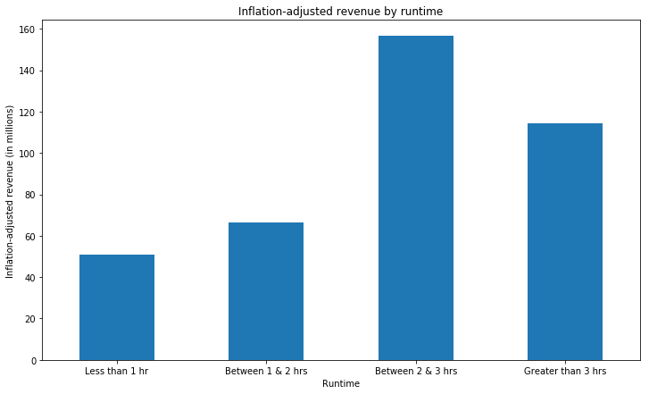

```python
#plotting
revdf.plot(x = 'runtime_summary',y = 'rev_adj_mil', kind='bar',cmap= 'tab20',figsize =(12,7),legend = False)
plt.xticks(rotation = 0)
plt.xlabel('Runtime')
plt.ylabel('Inflation-adjusted revenue (in millions)')
plt.title('Inflation-adjusted revenue by runtime')
```

**5.a Conclusion:** From the above bar plot, it can be observed that the revenue is highest between runtime of 2 and 3 hours. Hence, it might be profitable to produce the content between 2 & 3 hrs duration.

## Limitations

- Almost 50% of budgeted values and 60% of revenues are missing. These values are replaced by mean for the purpose of the analysis. Hence, analysis might change if those values are available
- The revenues of recent releases might increase over the years by selling the copyrights of it to the online streaming platforms

```python
pd.__version__
```

```
'0.23.3'
```

```python
from subprocess import call
call(['python', '-m', 'nbconvert', 'Investigate_a_Dataset.ipynb'])
```

```
0
```